# On the Prediction of Deliquencies

# 1 Introduction

This is an R Markdown document.

# 2 Libraries

```r
source("db.R")
library(smbinning)
library(InformationValue)
library(randomForest)
set.seed = 1
datapath = "C:/Users/tbountourelis/OneDrive - PURCHASING POWER, LLC/R Projects/Data/"
```

# 3 Read Data

The training data are read from a view called “v_mart_delinquency_train” into a csv file.

```r
data <- read.csv(file = paste(datapath, "v_mart_delinquency_train.csv", sep = ""))
data <- as.data.frame(unclass(data), stringsAsFactors=TRUE) # Make strings factors
cols <- c("ORDER_DT_HOUR", "ORDER_DT_MONTH", "CLIENT_ID_V2")
data[, cols] <- lapply(data[, cols], factor)
```

# 4 Creating Training and Test sets

Create train (70%) and testing (30%) tests.

```r
# Create Training Data
input.ones <- data[which(data$OUTCOME == 1), ]  # all 1's
input.zeros <-data[which(data$OUTCOME == 0), ]  # all 0's
# Create Test Data
input.ones.train.rows  <- sample(1:nrow(input.ones), 0.7 * nrow(input.ones))  # 1's for training
input.zeros.train.rows <- sample(1:nrow(input.zeros), 0.7 * nrow(input.zeros))  # 0's for training. Pick as many 0's as 1's
#
training.ones  <- input.ones[input.ones.train.rows, ]
training.zeros <- input.zeros[input.zeros.train.rows, ]
data.train <- rbind(training.ones, training.zeros)
#
test.ones  <- input.ones[-input.ones.train.rows, ]
test.zeros <- input.zeros[-input.zeros.train.rows, ]
data.test  <- rbind(test.ones, test.zeros)
```

# 5 Calculating the Information Value (IV) of Independent Variables

In this section we calculate the IV of each independent variable. The IV is a measure of the relationship between an independent and the dependent variable. As a rule of thumb, independent variables with an IV less than 0.02 are ignored. We calculate the corresponding IVs using the smbinning package.

We store the IV of all variables into df.iv.

```r
df.iv <- data.frame(Var=as.character(), IV=as.numeric())
lst.smb <- list()
```

## 5.1 Order Attributes

In this section we calculate the IV of Order attributes.

### 5.1.1 Product Type

A particular order may have multiple products. Products can be categorized to (i) Departments (Dept), (ii) Classes (Class), and (iii) Subclasses (Subclass).We review the IV of each of these attributes. We first look at the Product Department. The column DEPT_WOA contains the Weight of Evidence (WoE) for each department. The column DEPT_VAL contains the average deliquency for each department.

```r
var   <- 'WOE_DEPT'
smb   <- smbinning(data.train, y="OUTCOME", x=var)
df.iv <- rbind(df.iv, data.frame(Var=var, IV=smb$iv))
smb$iv
```

```
## [1] 0.0425
```

```r
smb$ivtable[, c("Cutpoint", "WoE")]
```

```
##     Cutpoint     WoE
## 1 <= -0.0746 -0.2981
## 2   <= 0.002 -0.1119
## 3  <= 0.0184  0.0199
## 4   > 0.0184  0.1750
## 5    Missing    -Inf
## 6      Total  0.0000
```

We repeat the same exercise for class.

```r
var <- 'WOE_CLASS'
smb <- smbinning(data.train, y="OUTCOME", x=var)
df.iv <- rbind(df.iv, data.frame(Var=var, IV=smb$iv))
smb$iv
```

```
## [1] 0.0274
```

```r
smb$ivtable[, c("Cutpoint", "WoE")]
```

```
##     Cutpoint     WoE
## 1 <= -0.0278 -0.1930
## 2  <= 0.0199 -0.0798
## 3  <= 0.0686  0.0861
## 4   > 0.0686  0.3295
## 5    Missing     NaN
## 6      Total  0.0000
```

We repeat the same exercise for Subclass.

```r
var = 'WOE_SUBCLASS'
smb <- smbinning(data.train, y="OUTCOME", x=var)
df.iv <- rbind(df.iv, data.frame(Var=var, IV=smb$iv))
smb$iv
```

```
## [1] 0.0074
```

```r
smb$ivtable[, c("Cutpoint", "WoE")]
```

```
##    Cutpoint     WoE
## 1 <= 0.0005 -0.0930
## 2 <= 0.0993  0.0625
## 3  > 0.0993  0.1688
## 4   Missing     NaN
## 5     Total  0.0000
```

### 5.1.2 Order Value

```r
var <- 'DEM'
smb <- smbinning(data.train, y="OUTCOME", x=var, p = 0.05)
lst.smb[[var]] <- smb
smb$ctree
```

```
##
## Model formula:
## OUTCOME ~ DEM
##
## Fitted party:
## [1] root
## |   [2] DEM <= 354.79
## |   |   [3] DEM <= 258.09: 0.119 (n = 8039, err = 842.3)
## |   |   [4] DEM > 258.09: 0.142 (n = 7867, err = 960.5)
## |   [5] DEM > 354.79: 0.175 (n = 93295, err = 13445.0)
##
## Number of inner nodes:    2
## Number of terminal nodes: 3
```

```r
smb$iv
```

```
## [1] 0.0149
```

```r
smb$ivtable[, c("Cutpoint", "WoE")]
```

```
##    Cutpoint     WoE
## 1 <= 258.09 -0.4041
## 2 <= 354.79 -0.1972
## 3  > 354.79  0.0452
## 4   Missing     NaN
## 5     Total  0.0000
```

```r
var_bin <- paste(var, "_SMBIN", sep = "")
df.iv <- rbind(df.iv, data.frame(Var=var, IV=smb$iv))
data.train <- smbinning.gen(data.train, smb, chrname = var_bin)
data.test  <- smbinning.gen(data.test , smb, chrname = var_bin)
```

### 5.1.3 Discount

The variable DIS represent the % of discount applied to the order. We perform a form of supervised binning as follows:

```r
var <- 'DIS'
smb <- smbinning(data.train, y="OUTCOME", x=var)
lst.smb[[var]] <- smb
smb$ctree
```

```
##
## Model formula:
## OUTCOME ~ DIS
##
## Fitted party:
## [1] root
## |   [2] DIS <= 0.0969: 0.183 (n = 63478, err = 9509.4)
## |   [3] DIS > 0.0969
## |   |   [4] DIS <= 0.1827: 0.153 (n = 27796, err = 3607.8)
## |   |   [5] DIS > 0.1827: 0.137 (n = 17927, err = 2121.0)
##
## Number of inner nodes:    2
## Number of terminal nodes: 3
```

```r
smb$iv
```

```
## [1] 0.0185
```

```r
smb$ivtable[, c("Cutpoint", "WoE")]
```

```
##    Cutpoint     WoE
## 1 <= 0.0969  0.1056
## 2 <= 0.1827 -0.1104
## 3  > 0.1827 -0.2409
## 4   Missing     NaN
## 5     Total  0.0000
```

```r
var_bin <- paste(var, "_SMBIN", sep = "")
df.iv <- rbind(df.iv, data.frame(Var=var, IV=smb$iv))
data.train <- smbinning.gen(data.train, smb, chrname = var_bin)
data.test  <- smbinning.gen(data.test , smb, chrname = var_bin)
```

### 5.1.4 Order Ship Type

```r
var <- 'SHIPTYPE'
smb <- smbinning.factor(data.train, y="OUTCOME", x=var)
lst.smb[[var]] <- smb
df.iv <- rbind(df.iv, data.frame(Var=var, IV=smb$iv))
smb$iv
```

```
## [1] 0.0127
```

### 5.1.5 Time

```r
var = 'ORDER_DT_HOUR'
smb <- smbinning.factor(data.train, y="OUTCOME", x=var, maxcat = 50)
df.iv <- rbind(df.iv, data.frame(Var=var, IV=smb$iv))
smb$iv
```

```
## [1] 0.0047
```

```r
var = 'ORDER_DT_MONTH'
smb <- smbinning.factor(data.train, y="OUTCOME", x=var, maxcat = 50)
df.iv <- rbind(df.iv, data.frame(Var=var, IV=smb$iv))
smb$ctree
```

```r
smb$iv
```

```
## [1] 0.0063
```

## 5.2 Buyer Attributes

In this section we calculate the IV of Buyer attributes.

### 5.2.1 Time between Registration and First Purchase

```r
var = 'DAYS_SINCE_REG'
smb <- smbinning(data.train, y="OUTCOME", x=var, p= 0.05)
lst.smb[[var]] <- smb
smb$iv
```

```
## [1] 0.0881
```

```r
smb$ivtable[, c("Cutpoint", "WoE")]
```

```
##   Cutpoint     WoE
## 1     <= 2  0.1412
## 2    <= 79  0.0413
## 3   <= 402  0.1614
## 4   <= 658 -0.0949
## 5  <= 1087 -0.5399
## 6   > 1087 -0.9718
## 7  Missing     NaN
## 8    Total  0.0000
```

```r
var_bin <- paste(var, "_SMBIN", sep = "")
df.iv <- rbind(df.iv, data.frame(Var=var, IV=smb$iv))
data.train <- smbinning.gen(data.train, smb, chrname = var_bin)
data.test  <- smbinning.gen(data.test , smb, chrname = var_bin)
```

### 5.2.2 Geography

```r
var <- 'WOE_STATE'
smb <- smbinning(data.train, y="OUTCOME", x=var)
lst.smb[[var]] <- smb
smb$iv
```

```
## [1] 0.0159
```

```r
smb$ctree
```

```
##
## Model formula:
## OUTCOME ~ WOE_STATE
##
## Fitted party:
## [1] root
## |   [2] WOE_STATE <= 0.0267
## |   |   [3] WOE_STATE <= -0.1358: 0.143 (n = 22829, err = 2794.5)
## |   |   [4] WOE_STATE > -0.1358: 0.162 (n = 38474, err = 5212.4)
## |   [5] WOE_STATE > 0.0267
## |   |   [6] WOE_STATE <= 0.2481: 0.182 (n = 39901, err = 5938.4)
## |   |   [7] WOE_STATE > 0.2481: 0.204 (n = 7997, err = 1297.2)
##
## Number of inner nodes:    3
## Number of terminal nodes: 4
```

```r
smb$ivtable[, c("Cutpoint", "WoE")]
```

```
##     Cutpoint     WoE
## 1 <= -0.1358 -0.1936
## 2  <= 0.0267 -0.0478
## 3  <= 0.2481  0.0953
## 4   > 0.2481  0.2353
## 5    Missing     NaN
## 6      Total  0.0000
```

```r
var_bin <- paste(var, "_SMBIN", sep = "")
df.iv <- rbind(df.iv, data.frame(Var=var, IV=smb$iv))
data.train <- smbinning.gen(data.train, smb, chrname = var_bin)
data.test  <- smbinning.gen(data.test , smb, chrname = var_bin)
```

### 5.2.3 UserGroup

```r
var <- 'USERGROUP'
smb <- smbinning.factor(data.train, y="OUTCOME", x=var, maxcat = 100)
lst.smb[[var]] <- smb
smb$iv
```

```
## [1] 0.0359
```

```r
smb$ivtable[, c("Cutpoint", "WoE")]
```

```
##                Cutpoint     WoE
## 1              = 'AFGE' -0.5312
## 2               = 'AJG' -0.3322
## 3           = 'ARIZONA'  0.8691
## 4              = 'ASEA' -0.5387
## 5     = 'BOISE_CASCADE' -0.0783
## 6              = 'CEHA' -0.1475
## 7               = 'CHS'  0.0779
## 8              = 'CSWG'  0.5887
## 9         = 'DELL_ONLY'  0.0952
## 10              = 'FCG' -0.8132
## 11          = 'FED_GOV'  0.1633
## 12            = 'KOHLS'  0.3962
## 13             = 'LEVI' -0.0326
## 14          = 'PC_ONLY' -0.1180
## 15 = 'PC_ONLY_18_MONTH' -0.0821
## 16     = 'PC_PLUS_APPS'  0.5914
## 17            = 'QUEST' -0.3670
## 18           = 'RETAIL'  0.2376
## 19         = 'STANDARD' -0.4808
## 20    = 'STD_PLUS_APPS'  0.0945
## 21              = 'TBK'  1.8863
## 22              = 'TWC'  0.1425
## 23            = 'TYSON'  0.4644
## 24              Missing     NaN
## 25                Total  0.0000
```

```r
#var <- 'USERGROUP_WOA'
#smb <- smbinning(data_train, y="OUTCOME", x=var)
#smb$iv
#smb$ctree

df.iv <- rbind(df.iv, data.frame(Var=var, IV=smb$iv))
```

### 5.2.4 Client (Affiliate)

```r
var <- 'WOE_CLIENT'
smb <- smbinning(data.train, y="OUTCOME", x=var)
lst.smb[[var]] <- smb
smb$iv
```

```
## [1] 0.1488
```

```r
smb$ctree
```

```
##
## Model formula:
## OUTCOME ~ WOE_CLIENT
##
## Fitted party:
## [1] root
## |   [2] WOE_CLIENT <= 0.224
## |   |   [3] WOE_CLIENT <= -0.494
## |   |   |   [4] WOE_CLIENT <= -0.649: 0.074 (n = 7407, err = 510.0)
## |   |   |   [5] WOE_CLIENT > -0.649: 0.097 (n = 5658, err = 497.3)
## |   |   [6] WOE_CLIENT > -0.494: 0.148 (n = 61690, err = 7784.4)
## |   [7] WOE_CLIENT > 0.224
## |   |   [8] WOE_CLIENT <= 0.624
## |   |   |   [9] WOE_CLIENT <= 0.382: 0.205 (n = 15528, err = 2529.9)
## |   |   |   [10] WOE_CLIENT > 0.382: 0.241 (n = 12687, err = 2321.4)
## |   |   [11] WOE_CLIENT > 0.624: 0.302 (n = 6231, err = 1314.4)
##
## Number of inner nodes:    5
## Number of terminal nodes: 6
```

```r
smb$ivtable[, c("Cutpoint", "WoE")]
```

```
##    Cutpoint     WoE
## 1 <= -0.649 -0.9225
## 2 <= -0.494 -0.6280
## 3  <= 0.224 -0.1508
## 4  <= 0.382  0.2428
## 5  <= 0.624  0.4520
## 6   > 0.624  0.7625
## 7   Missing     NaN
## 8     Total  0.0000
```

```r
var_bin <- paste(var, "_SMBIN", sep = "")
data.train <- smbinning.gen(data.train, smb, chrname = var_bin)
data.test  <- smbinning.gen(data.test , smb, chrname = var_bin)

df.iv <- rbind(df.iv, data.frame(Var=var, IV=smb$iv))
```

### 5.2.5 Client (Affiliate)

```r
var <- 'WOE_CLIENT'
i <- data.train$NEW_CHANNEL == 'Affiliate'
smb <- smbinning(data.train[i,], y="OUTCOME", x=var)
lst.smb[[var]] <- smb
smb$iv
```

```
## [1] 0.1841
```

```r
smb$ctree
```

```
##
## Model formula:
## OUTCOME ~ WOE_CLIENT
##
## Fitted party:
## [1] root
## |   [2] WOE_CLIENT <= 0.224
## |   |   [3] WOE_CLIENT <= -0.494
## |   |   |   [4] WOE_CLIENT <= -0.772: 0.060 (n = 4461, err = 252.8)
## |   |   |   [5] WOE_CLIENT > -0.772: 0.095 (n = 6887, err = 591.9)
## |   |   [6] WOE_CLIENT > -0.494
## |   |   |   [7] WOE_CLIENT <= -0.008
## |   |   |   |   [8] WOE_CLIENT <= -0.256: 0.122 (n = 9140, err = 982.0)
## |   |   |   |   [9] WOE_CLIENT > -0.256: 0.138 (n = 12988, err = 1547.6)
## |   |   |   [10] WOE_CLIENT > -0.008
## |   |   |   |   [11] WOE_CLIENT <= 0.156: 0.159 (n = 19023, err = 2548.1)
## |   |   |   |   [12] WOE_CLIENT > 0.156: 0.177 (n = 6879, err = 1003.6)
## |   [13] WOE_CLIENT > 0.224
## |   |   [14] WOE_CLIENT <= 0.634
## |   |   |   [15] WOE_CLIENT <= 0.363: 0.202 (n = 9959, err = 1607.9)
## |   |   |   [16] WOE_CLIENT > 0.363: 0.243 (n = 14307, err = 2632.5)
## |   |   [17] WOE_CLIENT > 0.634: 0.314 (n = 4869, err = 1048.9)
##
## Number of inner nodes:    8
## Number of terminal nodes: 9
```

```r
smb$ivtable[, c("CntRec", "Cutpoint", "WoE")]
```

```
##    CntRec  Cutpoint     WoE
## 1    4461 <= -0.772 -1.1658
## 2    6887 <= -0.494 -0.6741
## 3    9140 <= -0.256 -0.3892
## 4   12988 <= -0.008 -0.2492
## 5   19023  <= 0.156 -0.0827
## 6    6879  <= 0.224  0.0461
## 7    9959  <= 0.363  0.2093
## 8   14307  <= 0.634  0.4447
## 9    4869   > 0.634  0.7991
## 10      0   Missing     NaN
## 11  88513     Total  0.0000
```

### 5.2.6 Client (non-Affiliate)

```r
var <- 'WOE_CLIENT'
i <- !is.na(data.train$NEW_CHANNEL) & data.train$NEW_CHANNEL != 'Affiliate'
smb <- smbinning(data.train[i,], y="OUTCOME", x=var)
#lst.smb[[var]] <- smb
smb$iv
```

```
## [1] 0.1031
```

```r
smb$ctree
```

```
##
## Model formula:
## OUTCOME ~ WOE_CLIENT
##
## Fitted party:
## [1] root
## |   [2] WOE_CLIENT <= 0
## |   |   [3] WOE_CLIENT <= -0.36
## |   |   |   [4] WOE_CLIENT <= -0.818: 0.104 (n = 1717, err = 160.3)
## |   |   |   [5] WOE_CLIENT > -0.818: 0.197 (n = 8879, err = 1402.7)
## |   |   [6] WOE_CLIENT > -0.36: 0.000 (n = 3973, err = 0.0)
## |   [7] WOE_CLIENT > 0: 0.217 (n = 6119, err = 1039.8)
##
## Number of inner nodes:    3
## Number of terminal nodes: 4
```

```r
smb$ivtable[, c("CntRec", "Cutpoint", "WoE")]
```

```
##   CntRec   Cutpoint     WoE
## 1   1717 <= -0.8179 -0.4720
## 2   8879   <= -0.36  0.2715
## 3   3973       <= 0    -Inf
## 4   6119        > 0  0.3958
## 5      0    Missing     NaN
## 6  20688      Total  0.0000
```

### 5.2.7 Days since Customer Launch

```r
var <- 'DAYS_SINCE_LAUNCH'
smb <- smbinning(data.train, y="OUTCOME", x=var)
lst.smb[[var]] <- smb
smb$iv
```

```
## [1] 0.2072
```

```r
smb$ctree
```

```
##
## Model formula:
## OUTCOME ~ DAYS_SINCE_LAUNCH
##
## Fitted party:
## [1] root
## |   [2] DAYS_SINCE_LAUNCH <= 66: 0.125 (n = 6379, err = 699.7)
## |   [3] DAYS_SINCE_LAUNCH > 66
## |   |   [4] DAYS_SINCE_LAUNCH <= 4616
## |   |   |   [5] DAYS_SINCE_LAUNCH <= 3195
## |   |   |   |   [6] DAYS_SINCE_LAUNCH <= 777: 0.168 (n = 21541, err = 3017.6)
## |   |   |   |   [7] DAYS_SINCE_LAUNCH > 777: 0.181 (n = 51291, err = 7619.5)
## |   |   |   [8] DAYS_SINCE_LAUNCH > 3195: 0.142 (n = 11732, err = 1432.3)
## |   |   [9] DAYS_SINCE_LAUNCH > 4616: 0.198 (n = 14917, err = 2368.4)
##
## Number of inner nodes:    4
## Number of terminal nodes: 5
```

```r
var_bin <- paste(var, "_SMBIN", sep = "")
df.iv <- rbind(df.iv, data.frame(Var=var, IV=smb$iv))
data.train <- smbinning.gen(data.train, smb, chrname = var_bin)
data.test  <- smbinning.gen(data.test , smb, chrname = var_bin)
```

### 5.2.8 Tenure

```r
var <- 'TENURE'
smb <- smbinning(data.train, y="OUTCOME", x=var)
lst.smb[[var]] <- smb
smb$iv
```

```
## [1] 0.3074
```

```r
smb$ctree
```

```
##
## Model formula:
## OUTCOME ~ TENURE
##
## Fitted party:
## [1] root
## |   [2] TENURE <= 30
## |   |   [3] TENURE <= 17
## |   |   |   [4] TENURE <= 11: 0.242 (n = 7654, err = 1402.3)
## |   |   |   [5] TENURE > 11
## |   |   |   |   [6] TENURE <= 13: 0.293 (n = 10080, err = 2088.7)
## |   |   |   |   [7] TENURE > 13: 0.252 (n = 12372, err = 2329.2)
## |   |   [8] TENURE > 17
## |   |   |   [9] TENURE <= 20: 0.224 (n = 6281, err = 1090.2)
## |   |   |   [10] TENURE > 20
## |   |   |   |   [11] TENURE <= 25: 0.197 (n = 8305, err = 1314.3)
## |   |   |   |   [12] TENURE > 25: 0.178 (n = 6797, err = 996.5)
## |   [13] TENURE > 30
## |   |   [14] TENURE <= 83
## |   |   |   [15] TENURE <= 42: 0.158 (n = 11327, err = 1508.5)
## |   |   |   [16] TENURE > 42
## |   |   |   |   [17] TENURE <= 52: 0.136 (n = 6268, err = 736.9)
## |   |   |   |   [18] TENURE > 52: 0.122 (n = 11703, err = 1253.0)
## |   |   [19] TENURE > 83
## |   |   |   [20] TENURE <= 126: 0.096 (n = 9605, err = 831.9)
## |   |   |   [21] TENURE > 126: 0.064 (n = 18809, err = 1126.1)
##
## Number of inner nodes:    10
## Number of terminal nodes: 11
```

```r
smb$ivtable[,c("Cutpoint", "WoE")]
```

```
##    Cutpoint     WoE
## 1     <= 11  0.4545
## 2     <= 13  0.7185
## 3     <= 17  0.5082
## 4     <= 20  0.3534
## 5     <= 25  0.1942
## 6     <= 30  0.0718
## 7     <= 42 -0.0730
## 8     <= 52 -0.2496
## 9     <= 83 -0.3756
## 10   <= 126 -0.6464
## 11    > 126 -1.0848
## 12  Missing     NaN
## 13    Total  0.0000
```

```r
df.iv <- rbind(df.iv, data.frame(Var=var, IV=smb$iv))
var_bin <- paste(var, "_SMBIN", sep = "")
data.train <- smbinning.gen(data.train, smb, chrname = var_bin)
data.test  <- smbinning.gen(data.test , smb, chrname = var_bin)
```

### 5.2.9 Client Eligibles

```r
var <- 'ELIGIBLES'
smb <- smbinning(data.train, y="OUTCOME", x=var)
lst.smb[[var]] <- smb
smb$iv
```

```
## [1] 0.0258
```

```r
smb$ctree
```

```
##
## Model formula:
## OUTCOME ~ ELIGIBLES
##
## Fitted party:
## [1] root
## |   [2] ELIGIBLES <= 149243
## |   |   [3] ELIGIBLES <= 60000
## |   |   |   [4] ELIGIBLES <= 15431: 0.183 (n = 40022, err = 5996.4)
## |   |   |   [5] ELIGIBLES > 15431
## |   |   |   |   [6] ELIGIBLES <= 26320: 0.132 (n = 9164, err = 1052.4)
## |   |   |   |   [7] ELIGIBLES > 26320
## |   |   |   |   |   [8] ELIGIBLES <= 29793: 0.208 (n = 5558, err = 916.1)
## |   |   |   |   |   [9] ELIGIBLES > 29793
## |   |   |   |   |   |   [10] ELIGIBLES <= 46925: 0.141 (n = 9636, err = 1167.3)
## |   |   |   |   |   |   [11] ELIGIBLES > 46925: 0.174 (n = 7927, err = 1138.5)
## |   |   [12] ELIGIBLES > 60000: 0.190 (n = 23692, err = 3641.6)
## |   [13] ELIGIBLES > 149243: 0.143 (n = 9938, err = 1217.1)
##
## Number of inner nodes:    6
## Number of terminal nodes: 7
```

```r
smb$ivtable[,c("Cutpoint", "WoE")]
```

```
##    Cutpoint     WoE
## 1  <= 15431  0.1058
## 2  <= 26320 -0.2816
## 3  <= 29793  0.2626
## 4  <= 46925 -0.2081
## 5  <= 60000  0.0399
## 6 <= 149243  0.1465
## 7  > 149243 -0.1929
## 8   Missing    -Inf
## 9     Total  0.0000
```

```r
var_bin <- paste(var, "_SMBIN", sep = "")
df.iv <- rbind(df.iv, data.frame(Var=var, IV=smb$iv))
data.train <- smbinning.gen(data.train, smb, chrname = var_bin)
data.test  <- smbinning.gen(data.test , smb, chrname = var_bin)
```

### 5.2.10 Verified Salary

```r
var = 'VERIFIEDSALARY'
smb <- smbinning(data.train, y="OUTCOME", x=var)
lst.smb[[var]] <- smb
smb$iv
```

```
## [1] 0.3902
```

```r
smb$ctree
```

```
##
## Model formula:
## OUTCOME ~ VERIFIEDSALARY
##
## Fitted party:
## [1] root
## |   [2] VERIFIEDSALARY <= 33284.16
## |   |   [3] VERIFIEDSALARY <= 27050.4
## |   |   |   [4] VERIFIEDSALARY <= 23924: 0.342 (n = 8257, err = 1858.2)
## |   |   |   [5] VERIFIEDSALARY > 23924: 0.326 (n = 7777, err = 1709.7)
## |   |   [6] VERIFIEDSALARY > 27050.4
## |   |   |   [7] VERIFIEDSALARY <= 31209: 0.266 (n = 13191, err = 2577.0)
## |   |   |   [8] VERIFIEDSALARY > 31209: 0.222 (n = 6952, err = 1200.0)
## |   [9] VERIFIEDSALARY > 33284.16: 0.115 (n = 66592, err = 6761.2)
##
## Number of inner nodes:    4
## Number of terminal nodes: 5
```

```r
smb$ivtable[,c("Cutpoint", "WoE")]
```

```
##        Cutpoint     WoE
## 1      <= 23924  0.9443
## 2    <= 27050.4  0.8739
## 3      <= 31209  0.5848
## 4 <= 33284.1601  0.3434
## 5  > 33284.1601 -0.4452
## 6       Missing -1.3777
## 7         Total  0.0000
```

```r
var_bin <- paste(var, "_SMBIN", sep = "")
df.iv <- rbind(df.iv, data.frame(Var=var, IV=smb$iv))
data.train <- smbinning.gen(data.train, smb, chrname = var_bin)
data.test  <- smbinning.gen(data.test , smb, chrname = var_bin)
```

## 5.3 Ordering Attributes

```r
df.iv <- df.iv[order(-df.iv$IV),]
df.iv
```

```
##                  Var     IV
## 16    VERIFIEDSALARY 0.3902
## 14            TENURE 0.3074
## 13 DAYS_SINCE_LAUNCH 0.2072
## 12        WOE_CLIENT 0.1488
## 9     DAYS_SINCE_REG 0.0881
## 1           WOE_DEPT 0.0425
## 11         USERGROUP 0.0359
## 2          WOE_CLASS 0.0274
## 15         ELIGIBLES 0.0258
## 5                DIS 0.0185
## 10         WOE_STATE 0.0159
## 4                DEM 0.0149
## 6           SHIPTYPE 0.0127
## 3       WOE_SUBCLASS 0.0074
## 8     ORDER_DT_MONTH 0.0063
## 7      ORDER_DT_HOUR 0.0047
```

# 6 A Logistic Regression Model

```r
models <- list()
models[["Orders"]] <- glm(OUTCOME ~ ORDER_DT_MONTH +
                          WOE_BIN_CLIENT +
                          WOE_BIN_DEPT +
                          WOE_BIN_CLASS +
                          WOE_BIN_DEM +
                          WOE_BIN_DIS +
                          WOE_BIN_DAYS_SINCE_REG +
                          WOE_BIN_STATE +
                          USERGROUP +
                          WOE_BIN_VERIFIEDSALARY +
                          WOE_BIN_TENURE
                          ,
                data=data.train,
                family=binomial(link="logit")
                )
logitMod <- models[["Orders"]]
summary(logitMod)
```

```
##
## Call:
## glm(formula = OUTCOME ~ ORDER_DT_MONTH + WOE_BIN_CLIENT + WOE_BIN_DEPT +
##     WOE_BIN_CLASS + WOE_BIN_DEM + WOE_BIN_DIS + WOE_BIN_DAYS_SINCE_REG +
##     WOE_BIN_STATE + USERGROUP + WOE_BIN_VERIFIEDSALARY + WOE_BIN_TENURE,
##     family = binomial(link = "logit"), data = data.train)
##
## Deviance Residuals:
##     Min       1Q   Median       3Q      Max
## -1.8060  -0.6340  -0.4335  -0.2606   3.0817
##
## Coefficients:
##                               Estimate Std. Error z value             Pr(>|z|)
## (Intercept)                 -8.0788728 55.7886343  -0.145             0.884859
## ORDER_DT_MONTH2             -0.0092487  0.0523944  -0.177             0.859884
## ORDER_DT_MONTH3             -0.0457625  0.0499578  -0.916             0.359654
## ORDER_DT_MONTH4              0.0540419  0.0494765   1.092             0.274713
## ORDER_DT_MONTH5              0.0621612  0.0489170   1.271             0.203818
## ORDER_DT_MONTH6              0.0432046  0.0497895   0.868             0.385535
## ORDER_DT_MONTH7              0.0629902  0.0474668   1.327             0.184496
## ORDER_DT_MONTH8              0.0215031  0.0476549   0.451             0.651827
## ORDER_DT_MONTH9             -0.0009939  0.0493711  -0.020             0.983939
## ORDER_DT_MONTH10             0.0083490  0.0481429   0.173             0.862321
## ORDER_DT_MONTH11            -0.0618470  0.0429686  -1.439             0.150051
## ORDER_DT_MONTH12            -0.0611382  0.0432206  -1.415             0.157197
## WOE_BIN_CLIENTBin 10        -0.8483679  0.1473365  -5.758  0.00000000851008935
## WOE_BIN_CLIENTBin 11        -0.7885601  0.0520538 -15.149 < 0.0000000000000002
## WOE_BIN_CLIENTBin 12        -1.1451672  0.0600907 -19.057 < 0.0000000000000002
## WOE_BIN_CLIENTBin 2         -0.1090298  0.0439403  -2.481             0.013090
## WOE_BIN_CLIENTBin 3         -0.2440297  0.0416739  -5.856  0.00000000475008217
## WOE_BIN_CLIENTBin 4         -0.4203111  0.0540538  -7.776  0.00000000000000750
## WOE_BIN_CLIENTBin 5         -0.4493205  0.0411156 -10.928 < 0.0000000000000002
## WOE_BIN_CLIENTBin 6         -0.3627631  0.0549900  -6.597  0.00000000004198581
## WOE_BIN_CLIENTBin 7         -1.5681743  0.0801254 -19.571 < 0.0000000000000002
## WOE_BIN_CLIENTBin 8         -0.4978149  0.0505576  -9.846 < 0.0000000000000002
## WOE_BIN_CLIENTBin 9         -0.8460688  0.0458873 -18.438 < 0.0000000000000002
## WOE_BIN_DEPTBin 1            8.7526239 55.7884452   0.157             0.875332
## WOE_BIN_DEPTBin 2            8.7349888 55.7884478   0.157             0.875581
## WOE_BIN_DEPTBin 3            8.5744948 55.7884557   0.154             0.877849
## WOE_BIN_DEPTBin 4            8.5292655 55.7884462   0.153             0.878488
```

[output cut: 127 more lines]

```
## WOE_BIN_TENUREBin 5         ***
## WOE_BIN_TENUREBin 6         ***
## WOE_BIN_TENUREBin 7         ***
## WOE_BIN_TENUREBin 8         ***
## WOE_BIN_TENUREBin 9         ***
## ---
## Signif. codes:  0 '***' 0.001 '**' 0.01 '*' 0.05 '.' 0.1 ' ' 1
##
## (Dispersion parameter for binomial family taken to be 1)
##
##     Null deviance: 98932  on 109200  degrees of freedom
## Residual deviance: 86550  on 109122  degrees of freedom
## AIC: 86708
##
## Number of Fisher Scoring iterations: 9
```

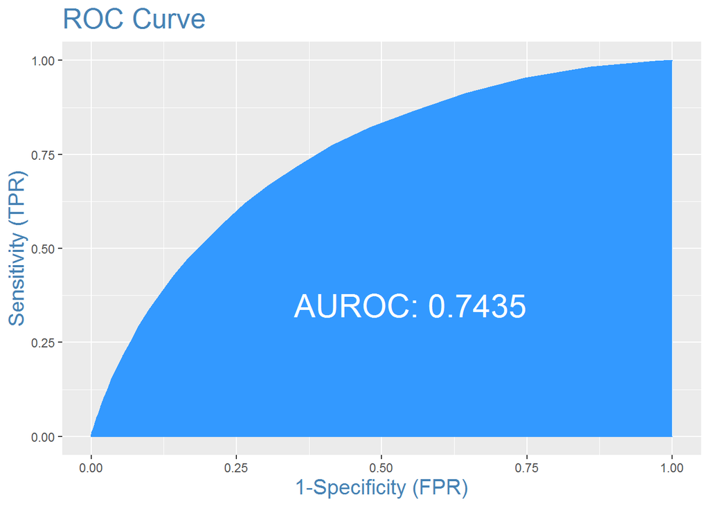

```r
data.test$predicted <- predict(logitMod, data.test, type="response")  # predicted scores

plotROC(data.test$OUTCOME, data.test$predicted)
```

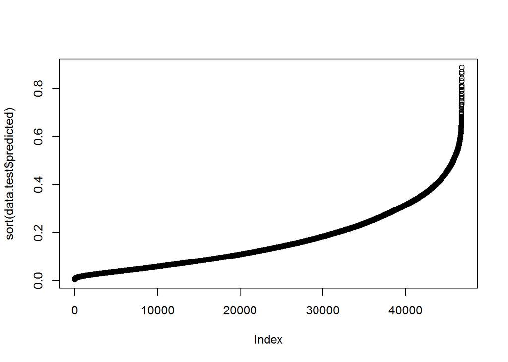

```r
plot(sort(data.test$predicted))
```

## 6.1 Validation

```r
df <- data.frame(OUTCOME=data.test$OUTCOME, predicted=data.test$predicted)
b <- seq(0, 1, 0.05)
df$Bins <- cut(df$predicted, breaks = b)

df.aggr.1 <- aggregate(df$OUTCOME, by=list(df$Bins), FUN = mean)
df.aggr.2 <- aggregate(df$OUTCOME, by=list(df$Bins), FUN = length)
```

How many orders do we capture for scores above 35%?

```r
v <- df.aggr.1$x * df.aggr.2$x
df.aggr.1$v <- v/sum(v)
df.aggr.1
```

```
##       Group.1          x            v
## 1    (0,0.05] 0.03159204 0.0322662602
## 2  (0.05,0.1] 0.07820042 0.1028963415
## 3  (0.1,0.15] 0.12347642 0.1183943089
## 4  (0.15,0.2] 0.17550949 0.1269054878
## 5  (0.2,0.25] 0.23235433 0.1246189024
## 6  (0.25,0.3] 0.27437155 0.1136941057
## 7  (0.3,0.35] 0.32540581 0.1095020325
## 8  (0.35,0.4] 0.37446121 0.0882876016
## 9  (0.4,0.45] 0.41389961 0.0680894309
## 10 (0.45,0.5] 0.46651532 0.0522103659
## 11 (0.5,0.55] 0.46691176 0.0322662602
## 12 (0.55,0.6] 0.49319728 0.0184197154
## 13 (0.6,0.65] 0.53846154 0.0071138211
## 14 (0.65,0.7] 0.72727273 0.0030487805
## 15 (0.7,0.75] 0.62500000 0.0006351626
## 16 (0.75,0.8] 0.85714286 0.0007621951
## 17 (0.8,0.85] 0.66666667 0.0005081301
## 18 (0.85,0.9] 1.00000000 0.0003810976
```

```r
i <- as.character(df.aggr.1$Group.1) >= "(0.35,"
sum(df.aggr.1[i,]$v)
```

```
## [1] 0.2717226
```

# 7 Is the Model Useful?

For the model to be useful there must be a threshold above which the cancellation of orders will result in a net benefit.

Each order has the following components: (i) Original Balance (BAL), (ii) Balance Paid (PAID), and (iii) Product Cost (COST). An order revenue can be expressed as PAID - COST. Generally, and ignoring additional costs, an order has a negative impact of PAID < COST.

Therefore, a model can be useful if orders above a certain threshold sum up to a negative order revenue.

```r
i <- !is.na(data.test$APPLIED) & !is.na(data.test$COST) & !is.na(data.test$predicted) & data.test$predicted >= 0.50
sum(data.test[i,]$APPLIED) / sum(1.1*data.test[i,]$COST)
```

```
## [1] 1.242259
```

Net Margin of these orders

```r
 (sum(data.test[i,]$ORIGINAL) - 1.1*sum(data.test[i,]$COST))/sum(data.test[i,]$ORIGINAL)
```

```
## [1] 0.4379761
```

Total Net Margin

```r
 (sum(data.test$ORIGINAL) - 1.1*sum(data.test$COST))/sum(data.test$ORIGINAL)
```

```
## [1] 0.3941097
```

```r
i <- !is.na(data.test$predicted) & data.test$predicted >= 0.375
sum(i)
```

```
## [1] 3997
```

```r
sum(i)/length(i)
```

```
## [1] 0.08540233
```

## 7.1 Save Objects

```r
save(models, lst.smb, file = paste(datapath, "model_Orders.Rdata", sep = ""))

table <- "mart_order_holdout"
data.out <- data.test[, c("ORDER_ID", "CUSTOMER_ID")]
con <- openCon()
sqlDrop(channel = con,
        sqtable = table,
        errors = FALSE)
sqlSave(channel = con,
        dat = data.out,
        tablename = table,
        append   = FALSE,
        rownames = FALSE,
        colnames = FALSE,
        verbose  = FALSE,
        safer    = TRUE,
        addPK    = FALSE,
        fast     = TRUE,
        test     = FALSE,
        nastring = NULL
)
close(con)
```